# TwoSample $t$-test as a model comparison

André Meichtry

# 1 Simulation of data from model

Simulate some two-group-data from model with parameters $\mu_i$ and $\sigma$ assumed known:

- Means parameterization: $Y_{ij}=\mu_i+\epsilon_{ij}, i=1,2, j=1,...,n_i$, $\boxed{Y_{ij}\sim N(\mu_i,\sigma^2)}$
- Effects parameterization (Default in R): $Y_{ij}=\alpha+I_{group=1}\beta+\epsilon_{ij}$ with $\mu_1=\alpha$ and $\beta=\mu_2-\mu_1$.

```r
library(psych)
n <- 20
alpha <- 2
beta <- 3
sigma <-10
set.seed(10)
group <- as.factor(sample(c(0,1),n,replace=TRUE))
Y <- alpha+beta*(group==1)+rnorm(n,0,sigma)
headTail(data.frame(Y,group))
```

```
        Y group
1   13.02     0
2    9.56     0
3    2.62     1
4   14.87     1
...   ...  <NA>
17  -1.88     1
18  -3.72     1
19   3.98     1
20  -0.54     0
```

# 2 Description

```r
summary(Y)
```

```
   Min. 1st Qu.  Median    Mean 3rd Qu.    Max.
-19.191  -4.110   1.040   0.783   7.512  14.874
```

```r
by(Y,group,summary)
```

```
group: 0
   Min. 1st Qu.  Median    Mean 3rd Qu.    Max.
 -19.19   -3.41    1.18    1.34    8.88   13.02
------------------------------------------------------------
group: 1
   Min. 1st Qu.  Median    Mean 3rd Qu.    Max.
-16.853  -4.343   0.371   0.229   3.749  14.874
```

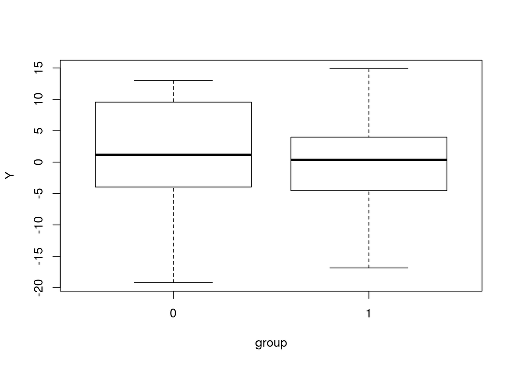

```r
boxplot(Y~group)
```

# 3 Classical test

```r
t.test(Y~group,var.equal=TRUE)
```

```
    Two Sample t-test

data:  Y by group
t = 0.261, df = 18, p-value = 0.8
alternative hypothesis: true difference in means is not equal to 0
95 percent confidence interval:
 -7.8096 10.0280
sample estimates:
mean in group 0 mean in group 1
        1.33773         0.22855
```

# 4 Model approach

## 4.1 Unrestricted model

$\mu_1$ and $\mu_2$ are unknown and have to be estimated:

```r
mod <- lm(Y~group)
summary(mod)
```

```
Call:
lm(formula = Y ~ group)

Residuals:
   Min     1Q Median     3Q    Max
-20.53  -4.91  -0.16   6.17  14.65

Coefficients:
            Estimate Std. Error t value Pr(>|t|)
(Intercept)     1.34       3.00    0.45     0.66
group1         -1.11       4.25   -0.26     0.80

Residual standard error: 9.49 on 18 degrees of freedom
Multiple R-squared:  0.00378,   Adjusted R-squared:  -0.0516
F-statistic: 0.0683 on 1 and 18 DF,  p-value: 0.797
```

```r
confint(mod)
```

```
               2.5 % 97.5 %
(Intercept)  -4.9688 7.6443
group1      -10.0280 7.8096
```

## 4.2 Restricted (“Null”) model

$H_0: \mu_2-\mu_1=0$ (Means parametrization) or $H_0: \beta=0$ (Effects parameterization). In this case, we have only one mean to be estimated.

```r
mod0 <- lm(Y~1)
summary(mod0)
```

```
Call:
lm(formula = Y ~ 1)

Residuals:
    Min      1Q  Median      3Q     Max
-19.974  -4.893   0.257   6.729  14.091

Coefficients:
            Estimate Std. Error t value Pr(>|t|)
(Intercept)    0.783      2.070    0.38     0.71

Residual standard error: 9.26 on 19 degrees of freedom
```

## 4.3 ANOVA for model comparison

```r
anova(mod0,mod)
```

```
Analysis of Variance Table

Model 1: Y ~ 1
Model 2: Y ~ group
  Res.Df  RSS Df Sum of Sq    F Pr(>F)
1     19 1628
2     18 1622  1      6.15 0.07    0.8
```

## 4.4 By hand

### 4.4.1 Residual sum of squares and explained sum of squares

```r
(RSS <-sum(mod$residuals^2))
```

```
[1] 1621.9
```

```r
(RSS0 <-sum(mod0$residuals^2))
```

```
[1] 1628.1
```

```r
(RSS0-RSS)
```

```
[1] 6.1514
```

Multiple R-squared. You find this quantity in the summary model output.

```r
(RSS0-RSS)/RSS0
```

```
[1] 0.0037783
```

### 4.4.2 degrees of freedom

```r
(df <- n-2)
```

```
[1] 18
```

```r
(df0 <- n-1)
```

```
[1] 19
```

### 4.4.3 $F$-test

The $F$-statistic is the amount of available fit that is actually achieved,
$$F=\frac{(RSS_0-RSS)/(df_0-df)}{RSS/df}=\frac{"Explained\,Mean Squares"}{"Not\,explained\,Mean Squares"}$$

```r
F <- (RSS0-RSS)/(df0-df)/(RSS/(df))
p <- 1-pf(F,df1=df0-df,df2=df)
sigma <- sqrt(RSS/df)
sigma0 <- sqrt(RSS0/df0)
print(data.frame(RSS0,RSS,SSExplained=RSS0-RSS,F,p,sigma,sigma0),row.names=FALSE)
```

```
   RSS0    RSS SSExplained        F       p  sigma sigma0
 1628.1 1621.9      6.1514 0.068268 0.79684 9.4925 9.2568
```

## 4.5 Log-Likelihood of both models*

These are the log-Likelhoods of the model at MLE’s (the maximum likelihood estimates).

```r
logLik(mod)
```

```
'log Lik.' -72.335 (df=3)
```

```r
logLik(mod0)
```

```
'log Lik.' -72.373 (df=2)
```

## 4.6 AIC and BIC (criterion for optimality)*

```r
AIC(mod0,mod)
```

```
     df    AIC
mod0  2 148.75
mod   3 150.67
```

```r
BIC(mod0,mod)
```

```
     df    BIC
mod0  2 150.74
mod   3 153.66
```

Smaller AIC and BIC (smaller negative penalized likelihoood) are better. We do NOT reject the constrained model in favor of the unconstrained model.